# Attrition at D.D.S. Analytics

Justin Howard

August 7, 2019

## Introduction

Data is the buzz-word of the twenty-first century. The rapid expansion of predictive analytics to fields outside the finance and manufacturing industries is opening new opportunities in every field. At D.D.S. Analytics, we are embarking on a project that will enhance our ability to provide our clients with a deeper understanding of their human capital flows, beginning with attrition. Every journey begins with a single step, and our first charge is to understand our employees. We focus mainly on attrition and its accompanying trends, but will also include a brief but instructive analysis of our current patterns related to compensation.

We explored the data to find surface-level trends using standard exploratory techniques and also used more advanced machine learning techniques to find hidden trends. We conducted a comparative review of three predictive classification models to choose the model that best identified the top three single factors that lead to attrition. Those factors and many other less important predictors had significant variance between their levels. To capture the influence of individual factor levels, we re-tooled the most predictive model to offer a more detailed, level-based analysis to examine which responses were the best predictors of attrition.

| Link to video presentation (please use Internet Explorer): https://www.screencast.com/t/MsRfs5V5a |
| --- |
| Link to GitHub repository: https://www.github.com/juhoward/CaseStudy2DDS |

# Data Description

The dataset examined has the following dimensions:

| Feature | Result |
| --- | --- |
| Number of observations | 870 |
| Number of variables | 36 |

# Codebook Summary Table

| Label | Variable | Class | # unique values | Missing | Description |
| --- | --- | --- | --- | --- | --- |
|  | **[ID]** | integer | 870 | 0.00 % | Employee ID Number |
|  | **[Age]** | integer | 43 | 0.00 % | Employee Age |
|  | **[Attrition]** | factor | 2 | 0.00 % | “Yes” or “No” if employee left company |
|  | **[BusinessTravel]** | factor | 3 | 0.00 % | Non-Travel, Travel_Frequently, Travel_Rarely |
|  | **[DailyRate]** | integer | 627 | 0.00 % | Daily pay |
|  | **[Department]** | factor | 3 | 0.00 % | Human Resources, Research & Dev., Sales |
|  | **[DistanceFromHome]** | integer | 29 | 0.00 % | Commute distance |
|  | **[Education]** | integer | 5 | 0.00 % | Levels of education from 1-5 |
|  | **[EducationField]** | factor | 6 | 0.00 % | Degree field |
|  | **[EmployeeCount]** | integer | 1 | 0.00 % | Number of employees |
|  | **[EmployeeNumber]** | integer | 870 | 0.00 % | Employee number |
|  | **[EnvironmentSatisfaction]** | integer | 4 | 0.00 % | Satisfaction rating from 1-4 |
|  | **[Gender]** | factor | 2 | 0.00 % | Male or Female |
|  | **[HourlyRate]** | integer | 71 | 0.00 % | Hourly pay |
|  | **[JobInvolvement]** | integer | 4 | 0.00 % | Employee’s expressed involvement in job |
|  | **[JobLevel]** | integer | 5 | 0.00 % | Employee rank |
|  | **[JobRole]** | factor | 9 | 0.00 % | Job title |
|  | **[JobSatisfaction]** | integer | 4 | 0.00 % | Employee’s satisfaction rating from 1-4 |
|  | **[MaritalStatus]** | factor | 3 | 0.00 % | Marital status from Divorced, Married, Single |
|  | **[MonthlyIncome]** | integer | 826 | 0.00 % | Monthly salary |
|  | **[MonthlyRate]** | integer | 852 | 0.00 % | Monthly rate of pay |
|  | **[NumCompaniesWorked]** | integer | 10 | 0.00 % | Number of companies worked for in the past |
|  | **[Over18]** | factor | 1 | 0.00 % | Yes for over 18 |
|  | **[OverTime]** | factor | 2 | 0.00 % | Yes or No for having worked overtime |
|  | **[PercentSalaryHike]** | integer | 15 | 0.00 % | Percentage of last raise in pay |
|  | **[PerformanceRating]** | integer | 2 | 0.00 % | Job skill rating from 1-4 |
|  | **[RelationshipSatisfaction]** | integer | 4 | 0.00 % | Employee satisfaction with their manager |
|  | **[StandardHours]** | integer | 1 | 0.00 % | Number of hours worked per week |
|  | **[StockOptionLevel]** | integer | 4 | 0.00 % | Vestagure in company stock |
|  | **[TotalWorkingYears]** | integer | 39 | 0.00 % | Total number of working years for employee |
|  | **[TrainingTimesLastYear]** | integer | 7 | 0.00 % | Number of trainings attended within 1 year |
|  | **[WorkLifeBalance]** | integer | 4 | 0.00 % | Employee rating from 1-4 |
|  | **[YearsAtCompany]** | integer | 32 | 0.00 % | Number of years at D.D.S. Analytics |
|  | **[YearsInCurrentRole]** | integer | 19 | 0.00 % | Number of years in current position |
|  | **[YearsSinceLastPromotion]** | integer | 16 | 0.00 % | Number of years since last promotion |
|  | **[YearsWithCurrManager]** | integer | 17 | 0.00 % | Number of years working with manager |

```
## 'data.frame':    870 obs. of  36 variables:
##  $ ID                      : int  1 2 3 4 5 6 7 8 9 10 ...
##  $ Age                     : int  32 40 35 32 24 27 41 37 34 34 ...
##  $ Attrition               : Factor w/ 2 levels "No","Yes": 1 1 1 1 1 1 1 1 1 1 ...
##  $ BusinessTravel          : Factor w/ 3 levels "Non-Travel","Travel_Frequently",..: 3 3 2 3 2 2 3 3 3 2 ...
##  $ DailyRate               : int  117 1308 200 801 567 294 1283 309 1333 653 ...
##  $ Department              : Factor w/ 3 levels "Human Resources",..: 3 2 2 3 2 2 2 3 3 2 ...
##  $ DistanceFromHome        : int  13 14 18 1 2 10 5 10 10 10 ...
##  $ Education               : int  4 3 2 4 1 2 5 4 4 4 ...
##  $ EducationField          : Factor w/ 6 levels "Human Resources",..: 2 4 2 3 6 2 4 2 2 6 ...
##  $ EmployeeCount           : int  1 1 1 1 1 1 1 1 1 1 ...
##  $ EmployeeNumber          : int  859 1128 1412 2016 1646 733 1448 1105 1055 1597 ...
##  $ EnvironmentSatisfaction : int  2 3 3 3 1 4 2 4 3 4 ...
##  $ Gender                  : Factor w/ 2 levels "Female","Male": 2 2 2 1 1 2 2 1 1 2 ...
##  $ HourlyRate              : int  73 44 60 48 32 32 90 88 87 92 ...
```

[output cut: 22 more lines]

Given the nature of the binary response variable, Attrition, we choose to build a logistic regression model to fit the data. Logistic regression requires us to meet some primary assumptions. These are the assumptions of the outcome being binary, linearity as it relates between the logit of the outcome and each predictor, the addressing of influential values in continuous predictors, and no high multicollinearity.

**Descriptive Statistics**

Significant departures from normality appear prevalent across all variables. A series of density plots will be used for further examination.

```
## # A tibble: 25 x 26
##    variable     n    na    mean      sd se_mean   IQR skewness kurtosis
##    <chr>    <dbl> <dbl>   <dbl>   <dbl>   <dbl> <dbl>    <dbl>    <dbl>
##  1 YearsSi~   870     0 2.17e+0 3.19e+0 1.08e-1    3     2.00    3.76
##  2 Perform~   870     0 3.15e+0 3.59e-1 1.22e-2    0     1.94    1.79
##  3 YearsAt~   870     0 6.96e+0 6.02e+0 2.04e-1    7     1.63    3.40
##  4 Monthly~   870     0 6.39e+3 4.60e+3 1.56e+2 5342.    1.39    1.16
##  5 TotalWo~   870     0 1.11e+1 7.51e+0 2.55e-1    9     1.14    1.11
##  6 JobLevel   870     0 2.04e+0 1.09e+0 3.70e-2    2     1.03    0.458
##  7 StockOp~   870     0 7.84e-1 8.58e-1 2.91e-2    1     1.03    0.516
##  8 NumComp~   870     0 2.73e+0 2.52e+0 8.55e-2    3     1.01   -0.0558
##  9 Distanc~   870     0 9.34e+0 8.14e+0 2.76e-1   12     0.915  -0.341
## 10 YearsIn~   870     0 4.20e+0 3.64e+0 1.23e-1    5     0.877   0.327
## # ... with 15 more rows, and 17 more variables: p00 <dbl>, p01 <dbl>,
## #   p05 <dbl>, p10 <dbl>, p20 <dbl>, p25 <dbl>, p30 <dbl>, p40 <dbl>,
## #   p50 <dbl>, p60 <dbl>, p70 <dbl>, p75 <dbl>, p80 <dbl>, p90 <dbl>,
## #   p95 <dbl>, p99 <dbl>, p100 <dbl>
```

We will proceed to examine both numerically coded and continuous variables for normality and homoscedasticity. Significant departures from normality are very clear across all continuous variables. Given the size of the dataset and the choice of logistic regression as the primary method of analysis, we will accept the departures in normality for the exmaination of attrition and use non-parametric classification techniques, such as KNN and Naive Bayes, that do not depend on the normal distribution. We will address these departures when we conduct our linear regression on Monthly Income.

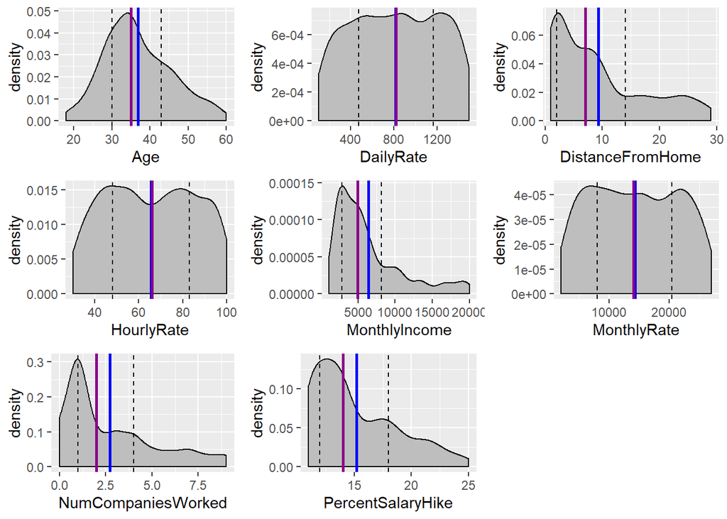

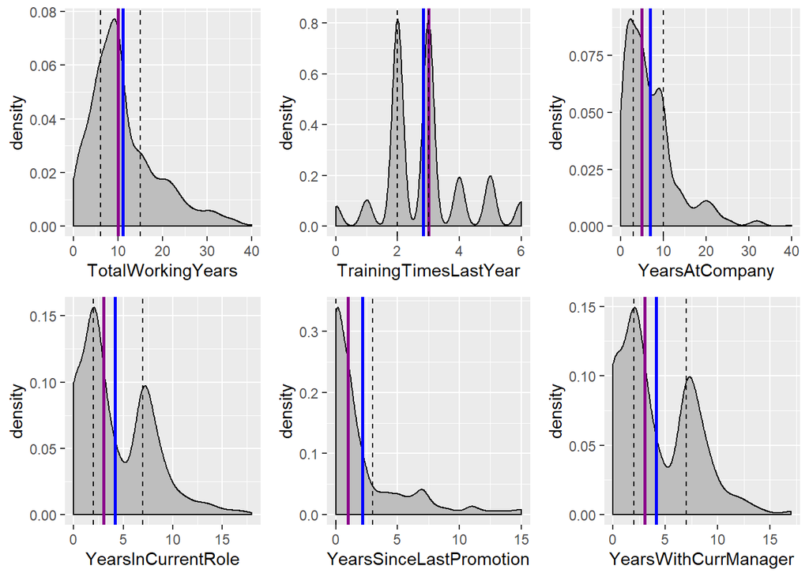

Linear relationships are difficult to ascertain except in the case of Age verses MonthlyIncome. A very clear linear relationship exists between the two variables. A clear, but less useful linear relationiship exists between YearsAtCompany, TotalWorkingYears and YearsInCurrentRole. A correlation matrix will be used to assess the Pearson’s R correlations between these variables and we will proceed with multicollinearity problems in mind.

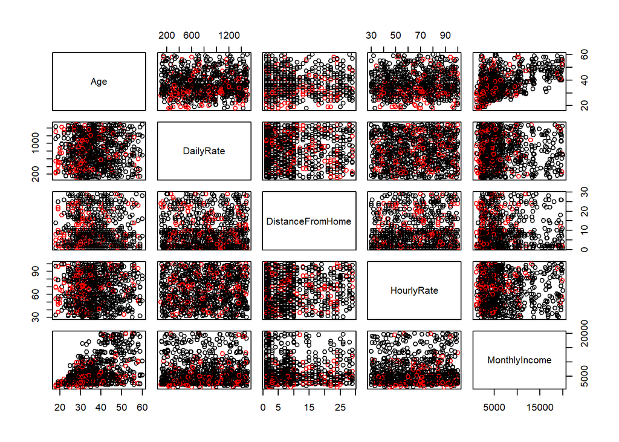

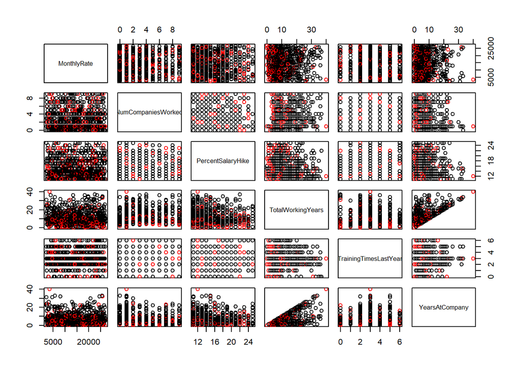

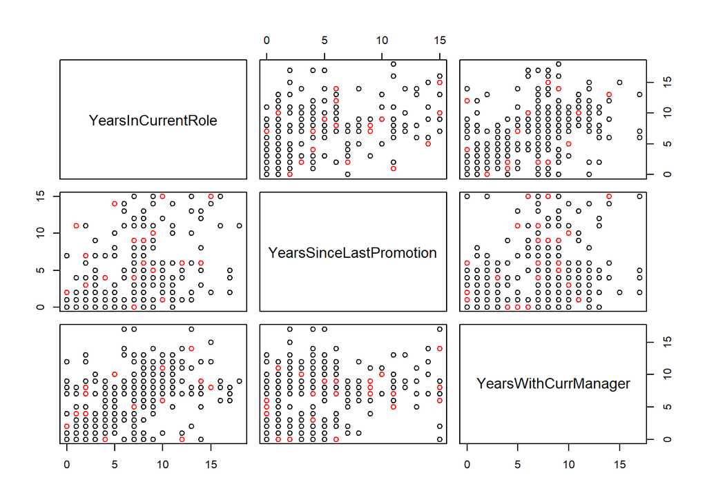

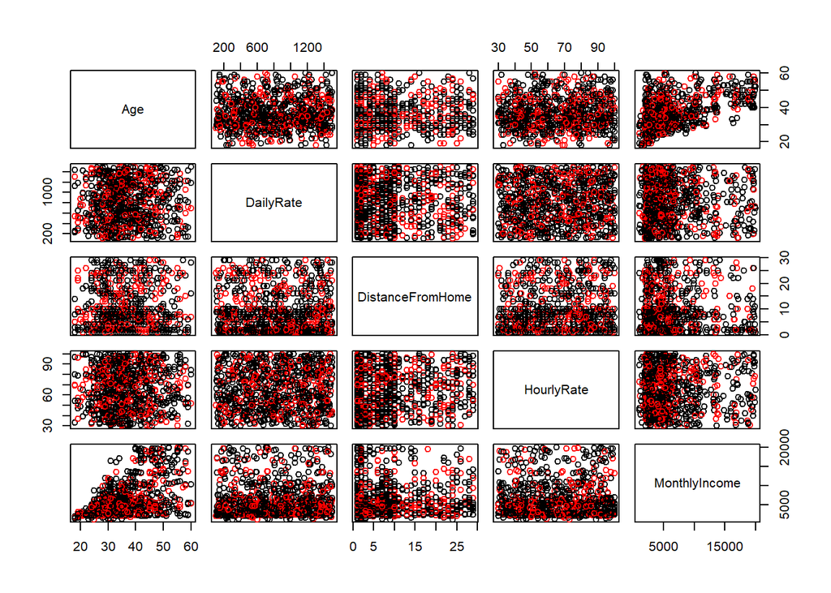

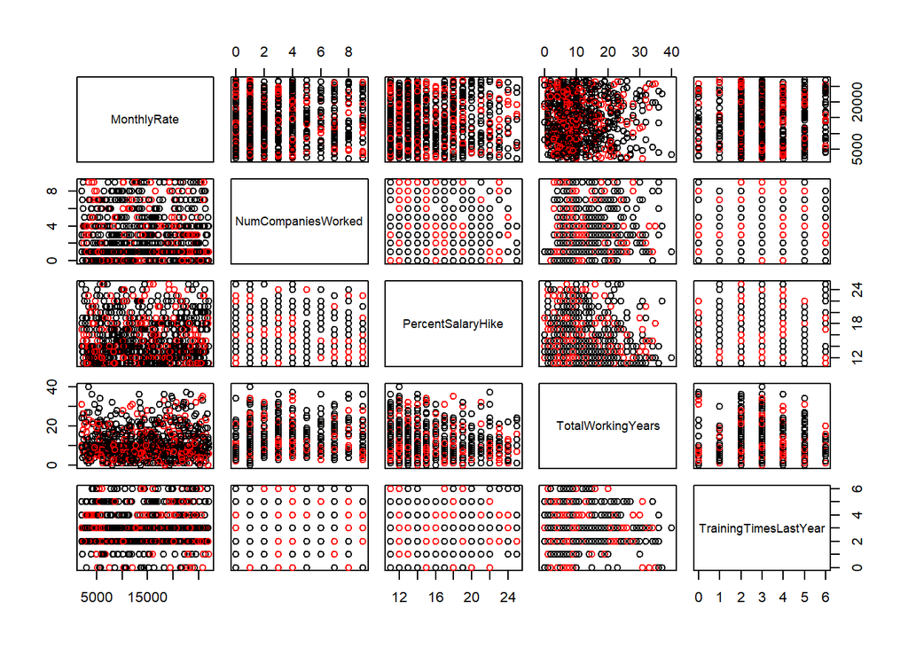

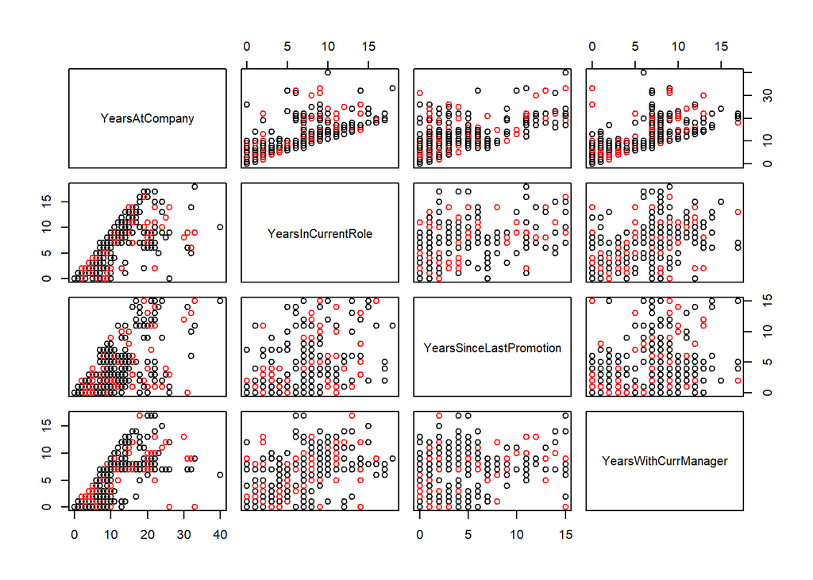

**A closer look at continuous variable relationships**

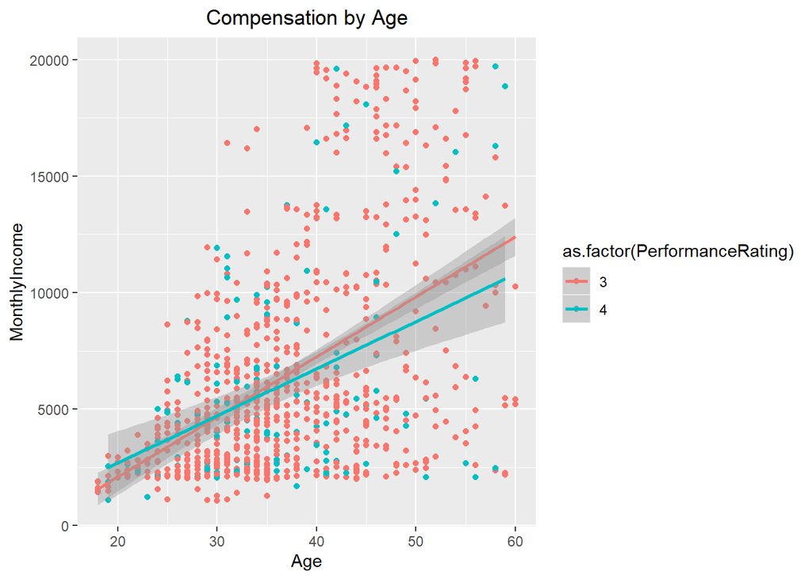

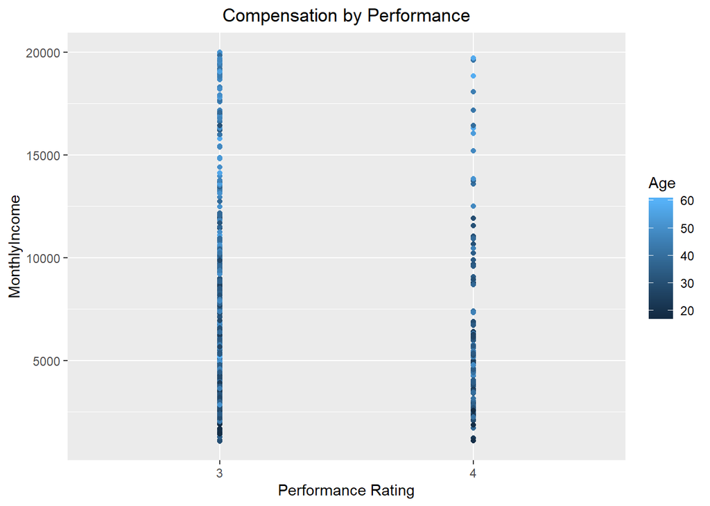

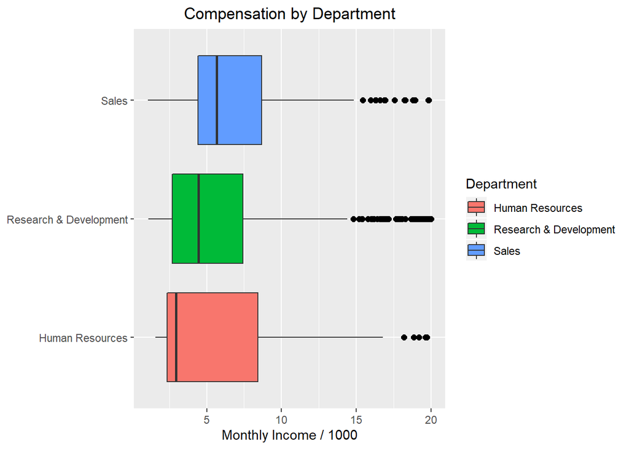

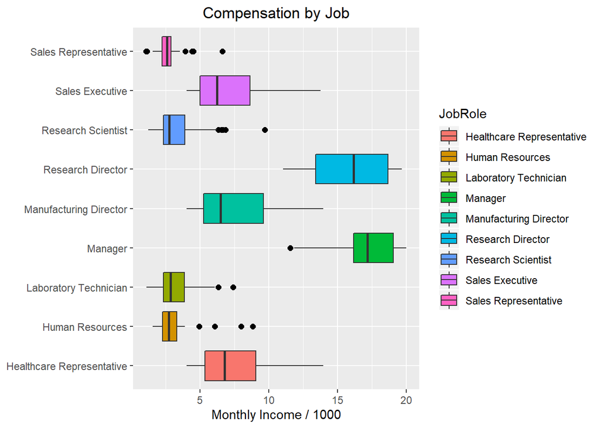

Signficant relationships exist between attrition and many of the following categorical variables:

[figure not shown]

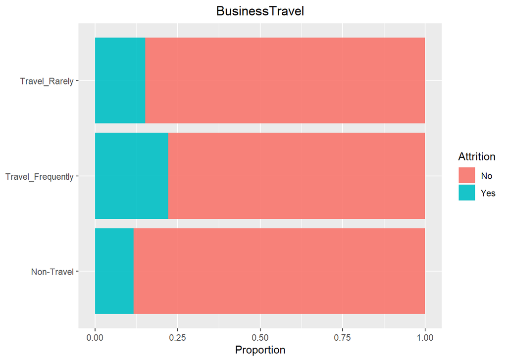

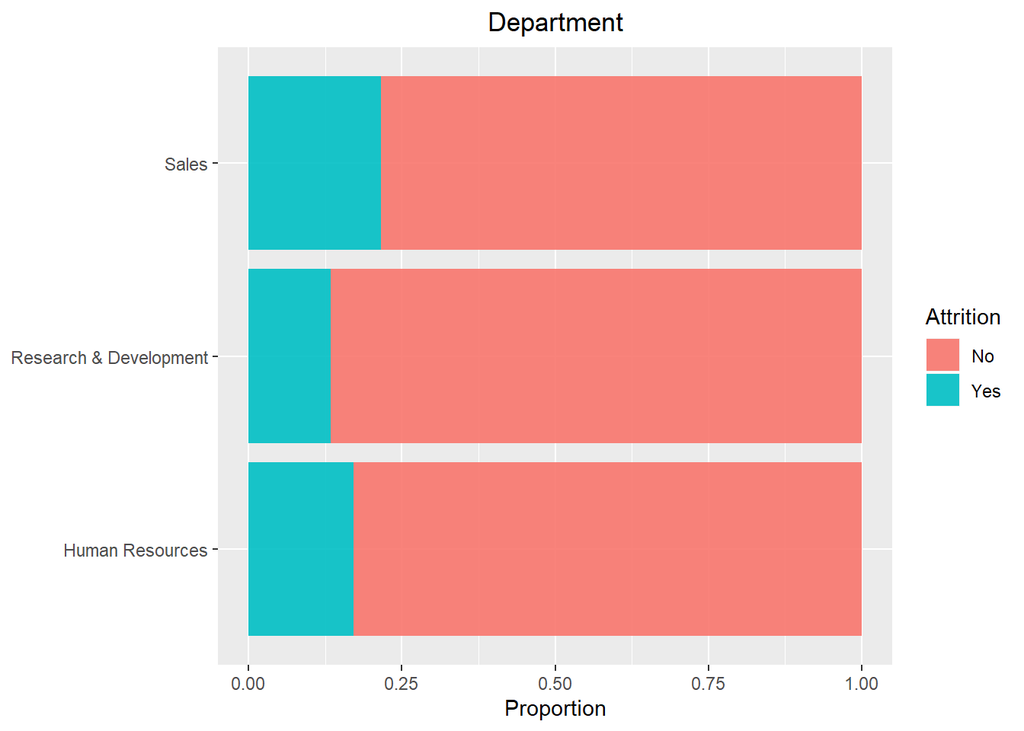

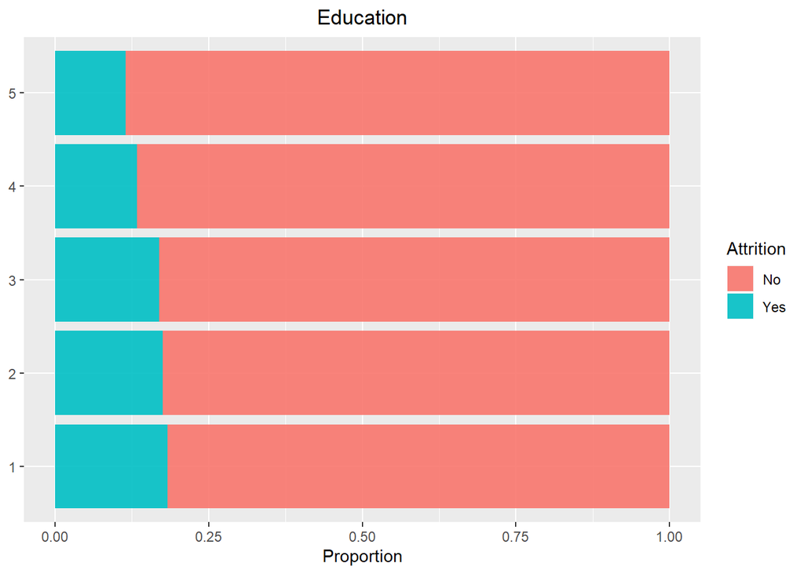

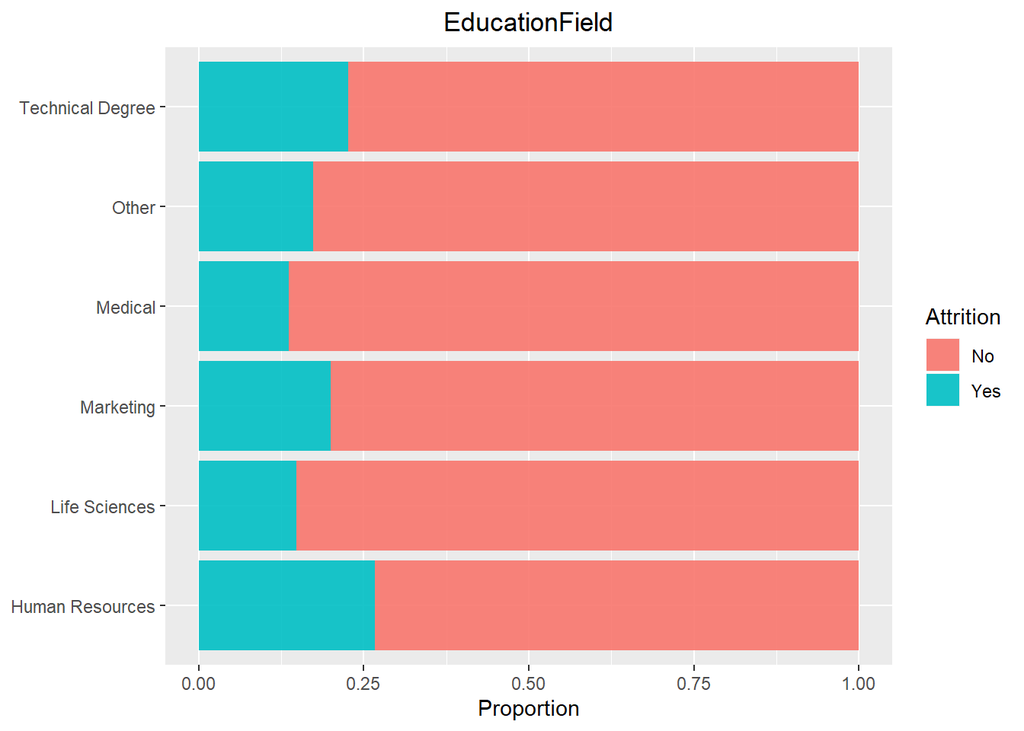

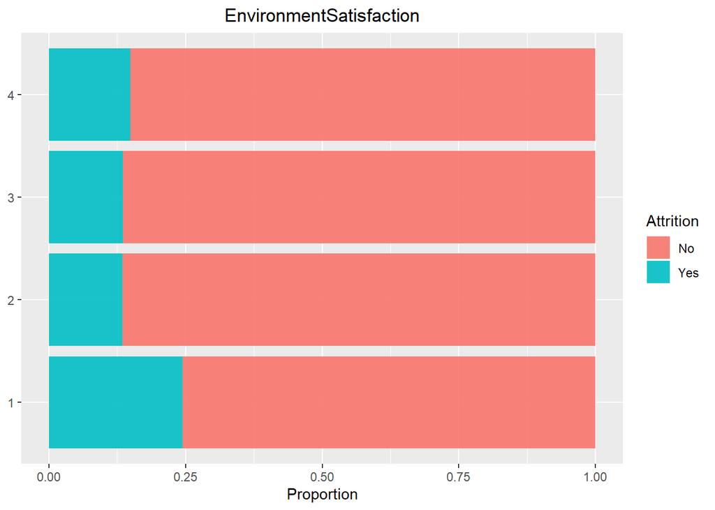

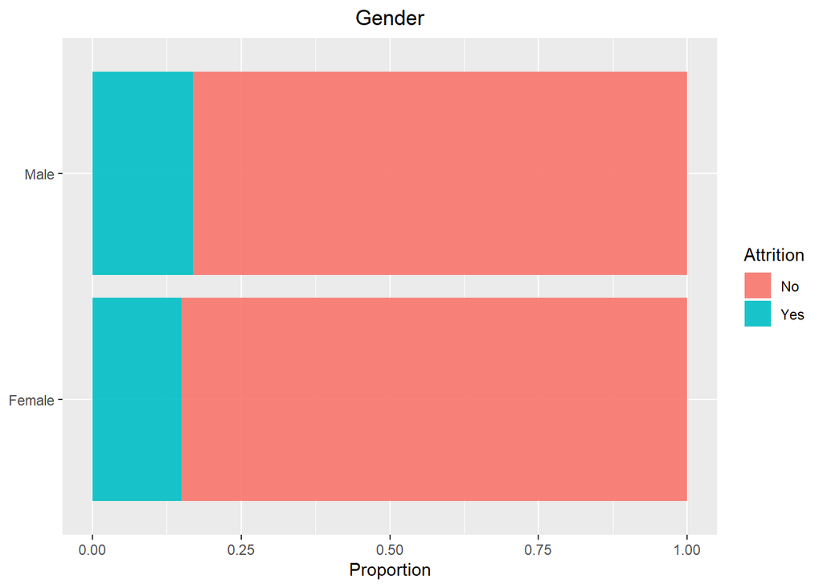

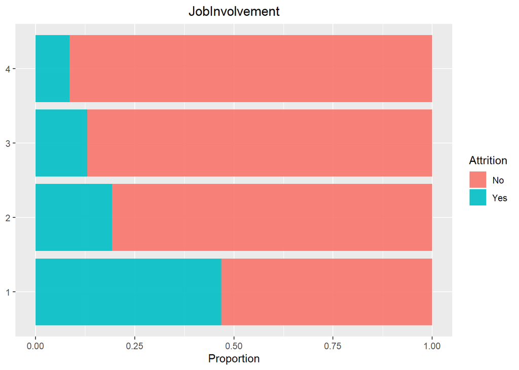

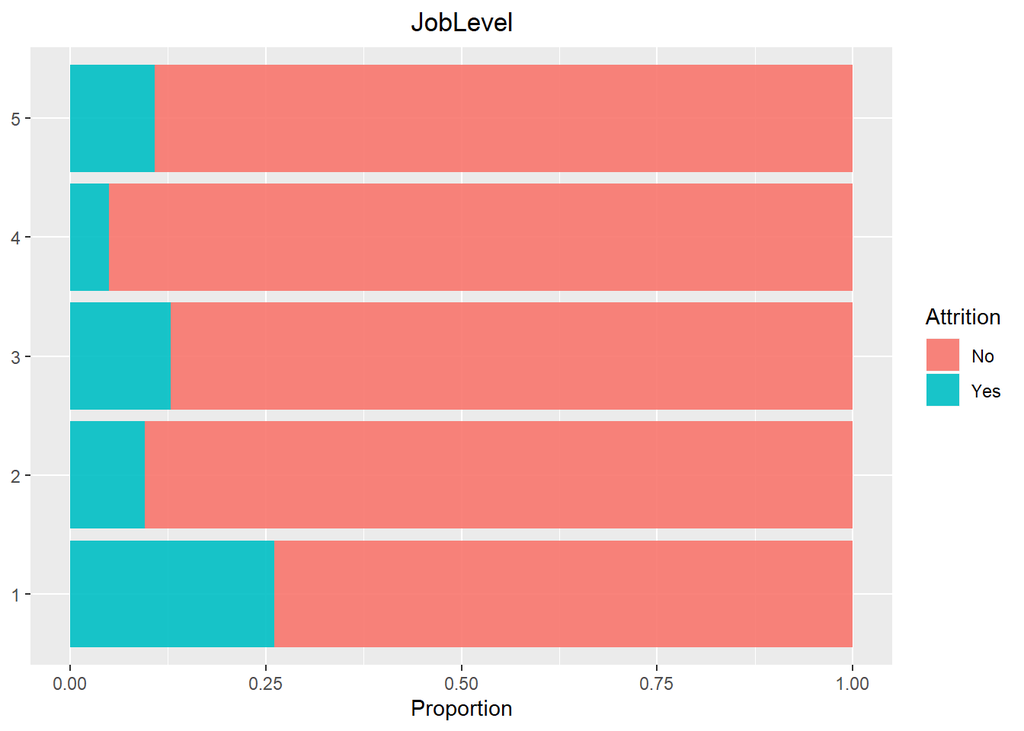

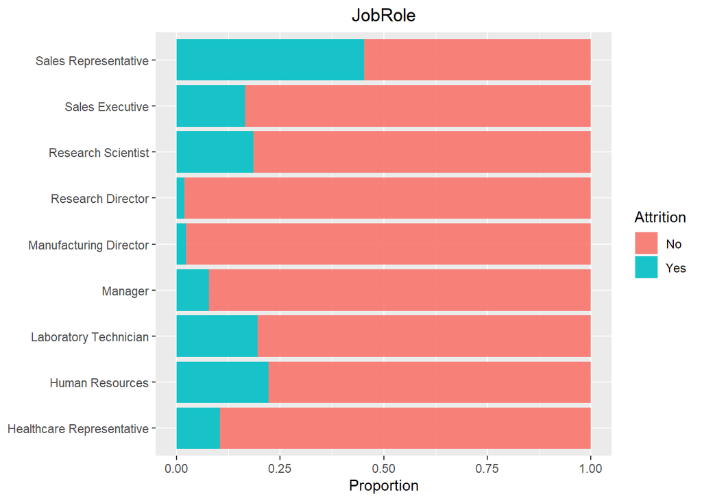

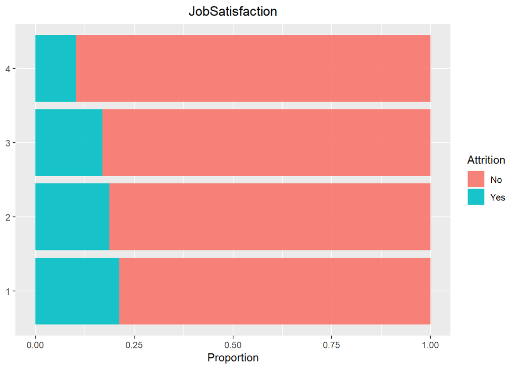

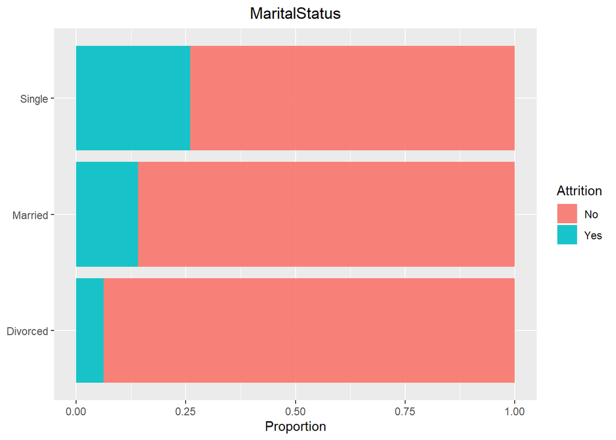

[5 more figures not shown]

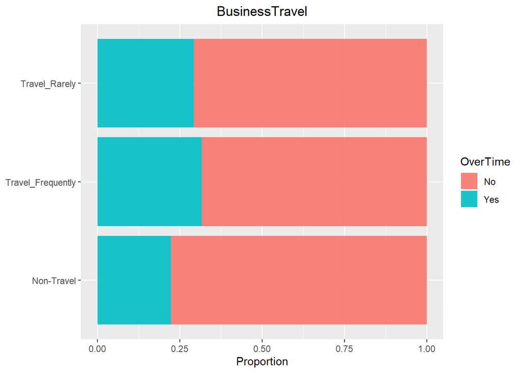

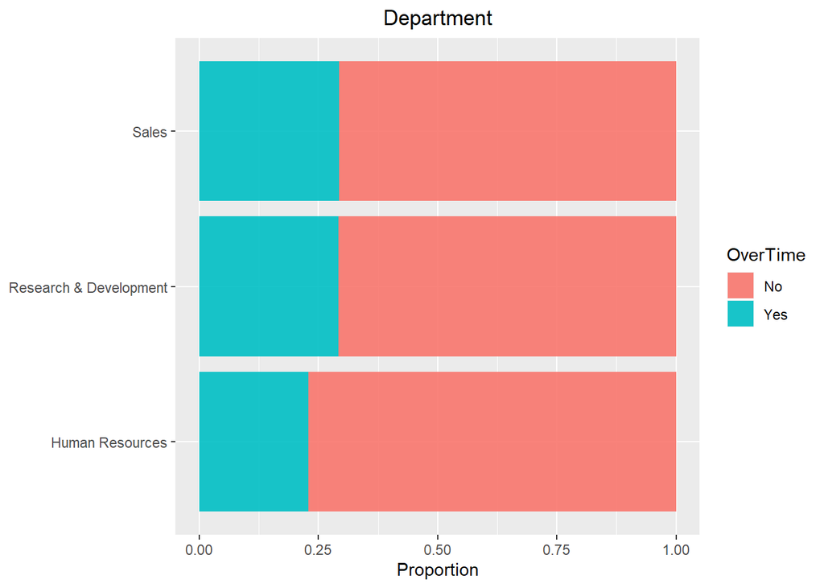

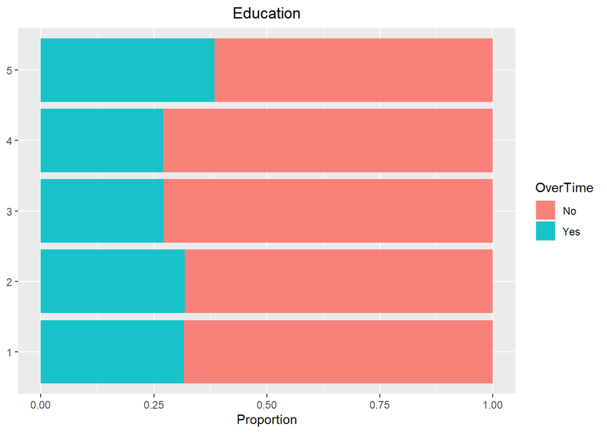

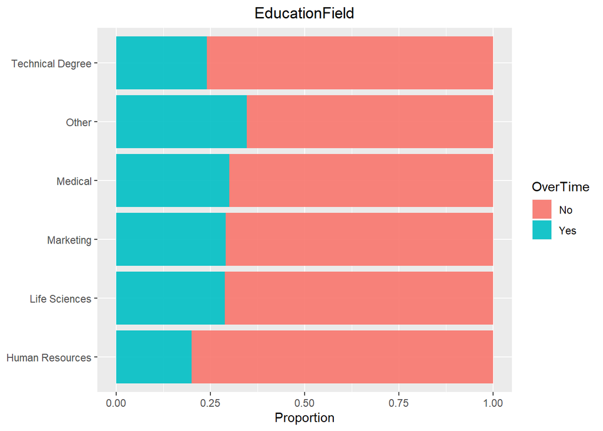

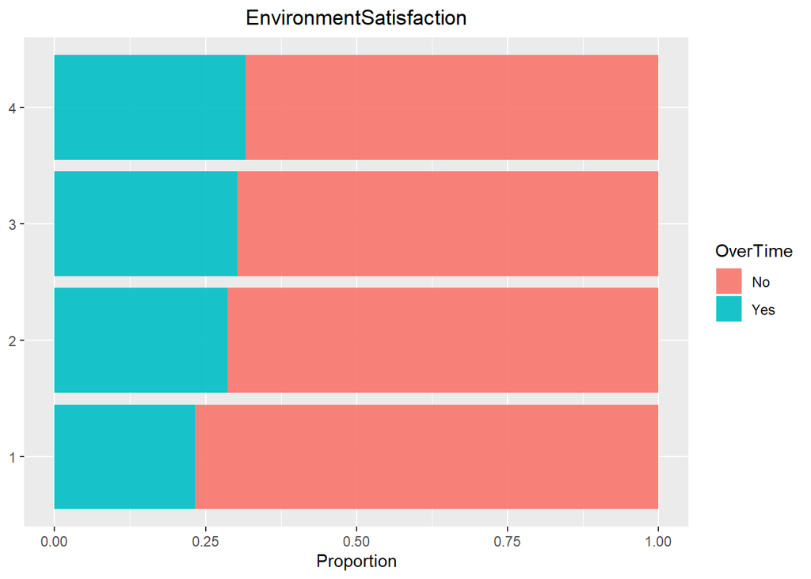

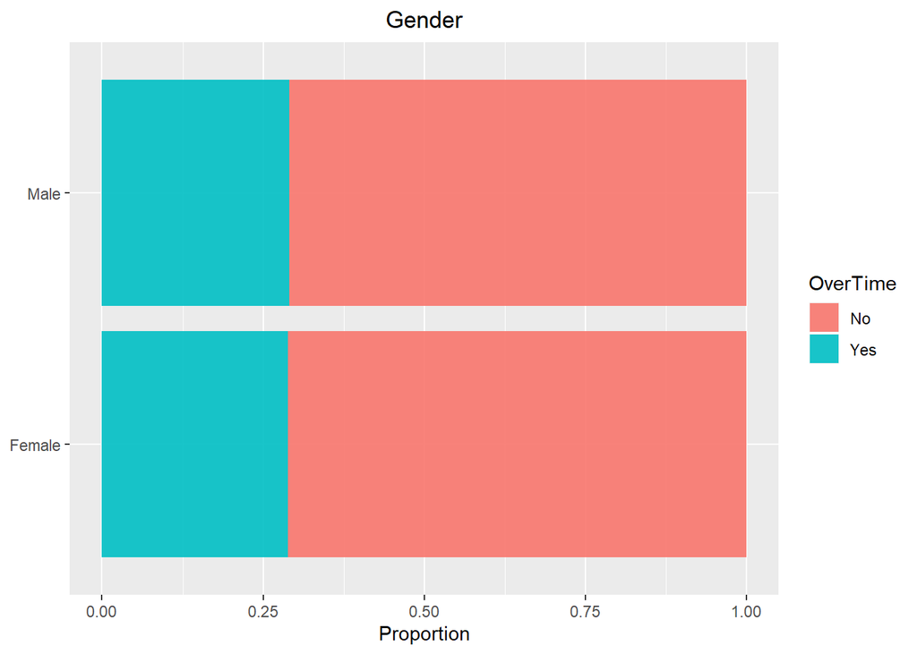

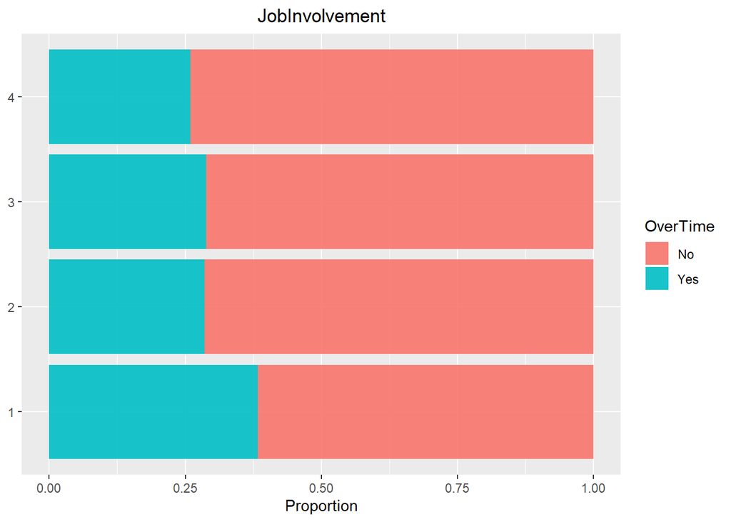